# R Notebook

```r
library(latex2exp)
library(ramify)
```

```r
library(imageseg)
library(caret)
library(tools)
library(xfun)
library(EBImage)
library(stringi)
library(ROCR)
library(pROC)
library(reticulate)
library(tensorflow)
library(keras)
library(keras3)
library(imager)
library(dplyr)
library(ggplot2)
library(purrr)
library(skimr)
library(tm)
library(RWeka)
library(e1071)
library(scales)
library(cutpointr)
library(magick)
library(superml)
library(grid)
library(crayon)
library(stringr)
library(cowplot)
library(patchwork)
# Set the working directory
setwd("C:/Ngoc/MastersThesis/Draft")

main_folder <- "MRI_brain_images/Axial"
class_folders <- list.dirs(main_folder, full.names = FALSE) # -> class_folders[1] is an empty string
class_folders <- stri_remove_empty(class_folders, na_empty = TRUE)
```

### A/ Find training and test set AUC for a built - from - scratch CNN model:

Unlike some preprocessing steps in tabular data (like normalization / standardization, filling in missing values, …), format conversion and resizing do not involve calculations and transformations based on data distributions that may affect the learning process of the model. These two steps are just used to ensure consistent input format and size for the model to work properly on the dataset. Therefore, instead of:

- Checking for any inconsistencies in the format of the images based on just the training set, then based on the result, convert all images from the training, validation and test set to the same format,
- As well as finding the range of image height and width from just the training set, then based on the result, resize all images to the same size,

We can:

- Check for any inconsistencies in the format of the images based on the whole dataset, then based on the result, convert all images from the training, validation and test set to the same format,
- As well as finding the range of image height and width from the whole dataset, then based on the result, resize all images to the same size.

For this approach, we only need to apply resizing and format conversion steps once at the begining then save the processed images for future code runs, instead of having to re - run these steps every time we split the train - validation - test set differently. This is practical and helps simplify the coding process.

#### 1. Check for any inconsistencies in the format of the images:

```r
# ############## Turn to comments from the second run onwards ###############
# num_gray = 0
# num_rgb = 0
# num_other = 0
#
# for (class_folder in class_folders){
#   directory <- file.path(main_folder, class_folder)
#   files <- list.files(directory, full.names = TRUE, pattern = "\\.jpg$")
#   for (file in files){
#     tryCatch(
#       {
#         img <- image_read(file)
#         info <- image_info(img)
#         if (info$colorspace == "Gray"){
#           num_gray = num_gray + 1
#         }
#         else if (info$colorspace == "sRGB"){
#             num_rgb = num_rgb + 1
#         }
#         else {
#           num_other = num_other + 1
#           cat("Image format: ", info$colorspace, "\n", file, "\n\n")
#         }
#       },
#       error = function(e)
#       {
#       cat("An exception occurred:", e$message, "\n", file, "\n\n")
#       })
#   }
# }
#
# cat("Number of Grayscale images:", num_gray, "\n")
# cat("Number of RGB images:", num_rgb, "\n")
# cat("Number of other types of images:", num_other, "\n")
#
# # -> The dataset contains 1026 images in Grayscale format and 2543 images in RGB format
```

#### **2.** Convert all images with RGB format into Grayscale format:

```r
# ############## Turn to comments from the second run onwards ###############
# for (class_folder in class_folders){
#   directory <- file.path(main_folder, class_folder)
#   files <- list.files(directory, full.names = TRUE, pattern = "\\.jpg$")
#   for (file in files){
#     tryCatch(
#       {
#         img <- image_read(file)
#         info <- image_info(img)
#         if (info$colorspace == "sRGB"){
#           # Turn RGB images into Grayscale, only keep values from the Red channel
#           img_gray <- image_channel(img, channel = "Red")
#
#           # Convert a magick object into a cimg image
#           image <- magick2cimg(img_gray)
#
#           # Save the change into the original dataset
#           save.image(image, file)
#         }
#       },
#       error = function(e)
#       {
#       cat("An exception occurred:", e$message, "\n", file, "\n\n")
#       })
#   }
# }
```

#### **3. Find the range of image height and width in the dataset:**

```r
# ############## Turn to comments from the second run onwards ###############
# min_width <- Inf
# max_width <- 0
# min_height <- Inf
# max_height <- 0
# widths <- list()
# heights <- list()
#
# for (class_folder in class_folders){
#   directory <- file.path(main_folder, class_folder)
#   files <- list.files(directory, full.names = TRUE, pattern = "\\.jpg$")
#   for (file in files){
#     tryCatch(
#       {
#         img <- load.image(file)
#         width <- dim(img)[1]
#         height <- dim(img)[2]
#         widths <- c(widths, width)
#         heights <- c(heights, height)
#
#         if (width < min_width){
#           min_width <- width
#         }
#         if (width > max_width){
#           max_width <- width
#         }
#         if (height < min_height){
#           min_height <- height
#         }
#         if (height > max_height){
#           max_height <- height
#         }
#       },
#       error = function(e)
#       {
#       cat("An exception occurred:", e$message, "\n", file, "\n\n")
#       })
#   }
# }
#
# cat("The range of image width:", min_width, " - ", max_width, "pixels \n")
# cat("The range of image height:", min_height, " - ", max_height, "pixels \n")
```

```r
# # Distribution of image widths and heights
# hist(unlist(widths), main = "Distribution of Image Widths",
#      xlab = "Width (pixels)", ylab = "Frequency", col = "lightblue",
#      xlim = c(0, 2000), ylim = c(0, 2000), border = "black")
#
# hist(unlist(heights), main = "Distribution of Image Heights",
#      xlab = "Height (pixels)", ylab = "Frequency", col = "lightblue",
#      xlim = c(0, 2500), ylim = c(0, 2000), border = "black")
```

#### 4. Resize all images into size 200 x 200 pixels:

```r
# ############## Turn to comments from the second run onwards ###############
# resize <- function(directory)
# {
#   files <- list.files(directory, full.names = TRUE, pattern = "\\.jpg$")
#   for (file in files)
#   {
#     tryCatch(
#       {
#       img <- image_read(file)
#
#       # Resize images and adds padding
#       img_resized <- image_resize(img, geometry = "200x200", filter = "Cubic")
#       img_resized_padding <- image_extent(img_resized, geometry = "200x200", gravity = "center", color = "black")
#
#       # Convert a magick object into a cimg image
#       image <- magick2cimg(img_resized_padding)
#
#       # Save the change into the original dataset
#       save.image(image, file)
#       },
#       error = function(e)
#       {
#       cat("An exception occurred:", e$message, "\n", file, "\n\n")
#       })
#   }
# }
#
# for (class_folder in class_folders) {
#   resize(file.path(main_folder, class_folder))
# }
```

#### 5. Get the list of images and the list of labels:

```r
# Get the list of image paths and the list of categorical labels
image_paths <- list()
labels <- list()
for (class_folder in class_folders) {
  images <- list.files(file.path(main_folder, class_folder), full.names = TRUE, pattern = "\\.jpg$")
  image_paths <- c(image_paths, images)
  labels <- c(labels, rep(class_folder, length(images)))
}

# Load the images
X <- lapply(unlist(image_paths), load.image)
```

#### 6. **Split training - test - validation set:**

```r
set.seed(1)

# Shuffle X and labels in the same order to make sure the label values appear in a random order
shuffle_indices <- sample(1:length(X))
X <- X[shuffle_indices]
labels <- labels[shuffle_indices]

# Split train : test : val as 70 : 20 : 10
train_indices_temp <- createDataPartition(unlist(labels), p = 0.8, list = FALSE)
test_indices <- setdiff(seq_along(unlist(labels)), train_indices_temp)
# -> seq_along(x) creates a sequence of integers with the same length as x

X_train_temp <- X[train_indices_temp]
labels_train_temp <- labels[train_indices_temp]
X_test <- X[test_indices]
labels_test <- labels[test_indices]

val_indices <- createDataPartition(unlist(labels_train_temp), p = 0.125, list = FALSE)
train_indices <- setdiff(seq_along(unlist(labels_train_temp)), val_indices)

X_train <- X_train_temp[train_indices]
labels_train <- labels_train_temp[train_indices]
X_val <- X_train_temp[val_indices]
labels_val <- labels_train_temp[val_indices]
# (train: 0.875 x 0.8 = 0.7 ; val: 0.125 x 0.8 = 0.1)

# Examine the size of the training, validation, and test sets
cat("Train set's size: X_train =", length(X_train), ", y_train =", length(labels_train), "\n")
```

```
## Train set's size: X_train = 2499 , y_train = 2499
```

```r
cat("Validation set's size: X_val =", length(X_val), ", y_val =", length(labels_val), "\n")
```

```
## Validation set's size: X_val = 358 , y_val = 358
```

```r
cat("Test set's size: X_test =", length(X_test), ", y_test =", length(labels_test), "\n")
```

```
## Test set's size: X_test = 712 , y_test = 712
```

```r
# Check the pixel value range of training images
cat("Pixel value range of training images: [", min(unlist(X_train)), ", ", max(unlist(X_train)), "] \n", sep = "")
```

```
## Pixel value range of training images: [0, 1]
```

```r
# -> All training images are already normalized
```

#### 7. Check for class distribution in training set:

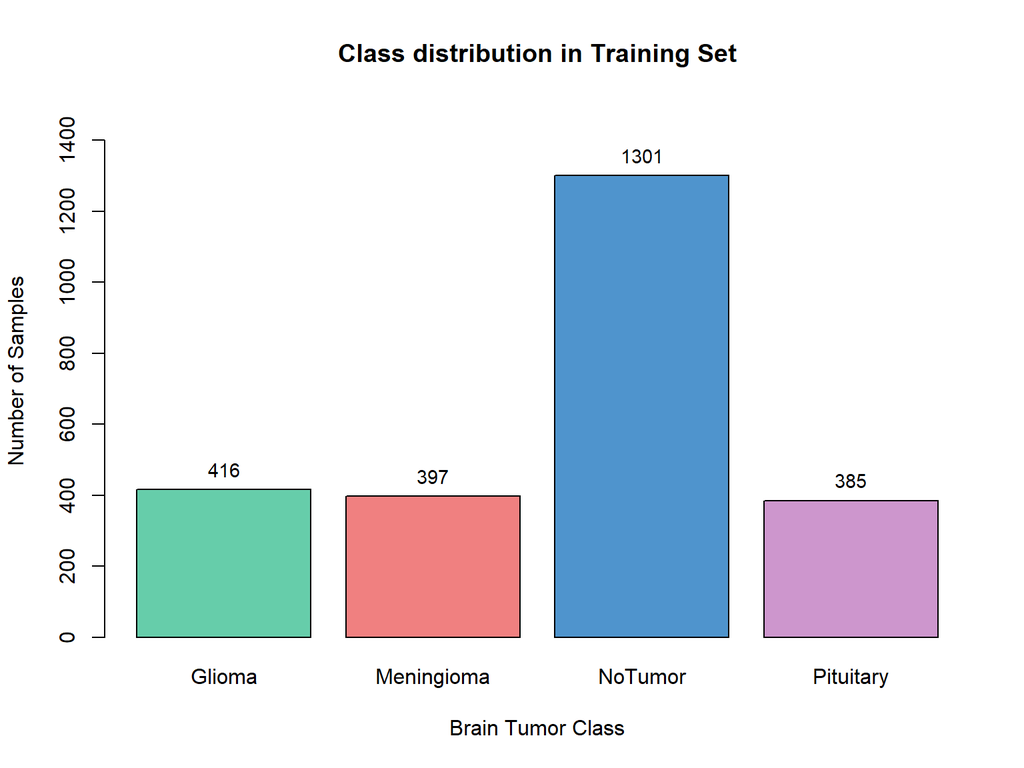

```r
count <- as.numeric(table(unlist(labels_train)))
bp <- barplot(table(unlist(labels_train)), main = "Class distribution in Training Set", col = c("aquamarine3", "lightcoral", "steelblue3", "plum3"), ylim = c(0, 1500), xlab = "Brain Tumor Class", ylab = "Number of Samples")
text(x = bp, y = count, label = count, cex = 0.9, pos = 3, col = "black")
```

#### 8. Apply other preprocessing steps:

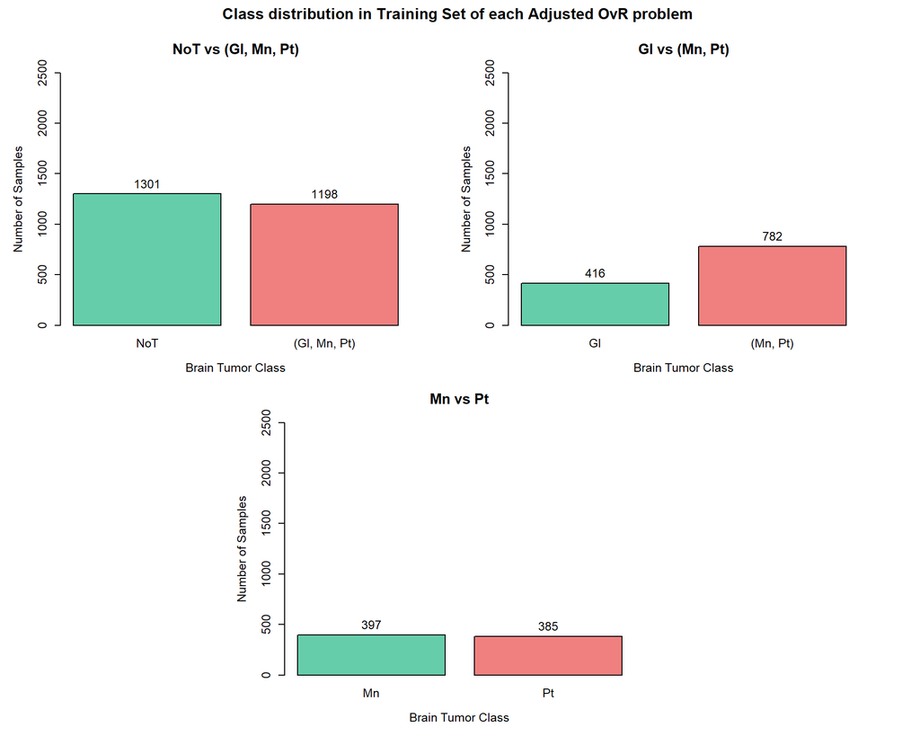

```r
class_counts <- sort(table(unlist(labels_train)), decreasing = TRUE)  # Sort the class names in decreasing order to minimize data imbalance in each Adjusted OvR problem
class <- names(class_counts)

label_map <- c("NoTumor" = "NoT", "Glioma" = "Gl", "Meningioma" = "Mn", "Pituitary" = "Pt")  # Shorten the labels

layout_ <- matrix(c(1, 1, 2, 2,
                    0, 3, 3, 0), nrow = 2, byrow = TRUE)

layout(layout_) # Create 3 subplots with 2 rows, centering the 3rd subplot
par(oma = c(1,1,2,1), mar = c(4,4,4,4)) # mar changes the spacing of each plot from (bottom, left, top, right)

# Check for class imbalance in training set of each model in OvR approach
for(i in 1:(length(class) - 1)){
  remaining_classes <- class[i:length(class)]
  labels_train_ovr_plt <- unlist(labels_train)[unlist(labels_train) %in% remaining_classes]

  # Convert the response variable to binary
  labels_train_ovr_plt <- ifelse(labels_train_ovr_plt == class[i], 1, 0)  # Returns result in numeric format
  labels_train_ovr_plt  <- factor(labels_train_ovr_plt, levels = c("1", "0"))  # Convert to factor, arrange the order of labels to be positive before negative for the barplot order

  # Check for class imbalance
  count <- as.numeric(table(labels_train_ovr_plt))
  neg_labels <- paste(label_map[remaining_classes[-1]], collapse = ", ")

  if (i == length(class) - 1) {
    # Last model - only two classes left
    custom_labels <- ifelse(names(table(labels_train_ovr_plt)) == "1", paste0(label_map[class[i]]), paste0(neg_labels))
    plot_title <- paste0(label_map[class[i]], " vs ", neg_labels)
    }
  else {
    # Other models
    custom_labels <- ifelse(names(table(labels_train_ovr_plt)) == "1", paste0(label_map[class[i]]), paste0("(", neg_labels, ")"))
    plot_title <- paste0(label_map[class[i]], " vs ", "(", neg_labels, ")")
    }
  bp <- barplot(table(labels_train_ovr_plt), names.arg = custom_labels, main = plot_title, cex.main = 1.4, cex.axis = 1.2, cex.lab = 1.2, cex.names = 1.2, col = c("aquamarine3", "lightcoral"), ylim = c(0, 2500), xlab = "Brain Tumor Class", ylab = "Number of Samples")
  text(x = bp, y = count, label = count, cex = 1.2, pos = 3, col = "black")
}

mtext(expression(bold("Class distribution in Training Set of each Adjusted OvR problem \n")), side = 3, line = -1.5, outer = TRUE)
```

```r
# -> Class pairs: All class pairs are not heavily imbalanced
# (Gl vs (Mn, Pt) only has mild imbalance with the ratio between the two classes being around 35:65)
```

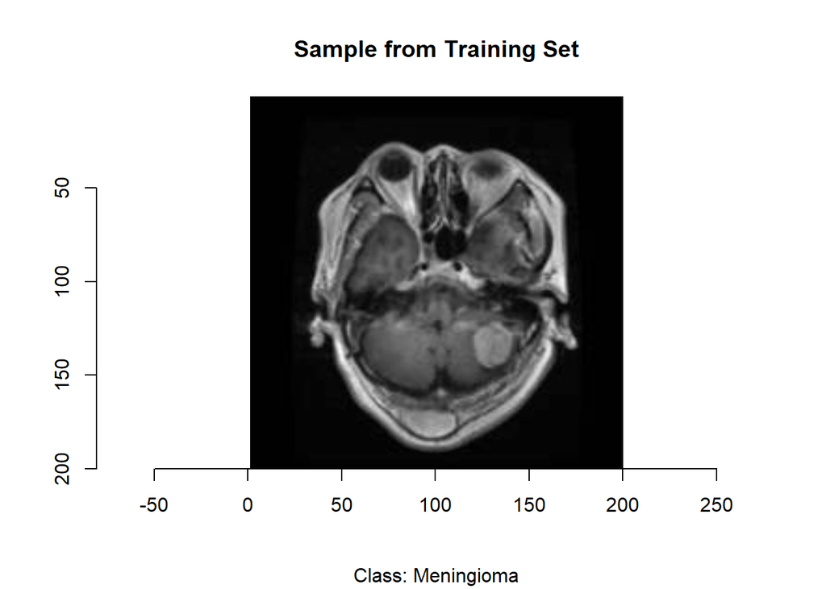

```r
# Reshape the images
xtr <- do.call(abind, X_train)
xv <- do.call(abind, X_val)
xte <- do.call(abind, X_test)

X_train_ <- aperm(xtr, perm = c(4,1,2,3))
X_val_ <- aperm(xv, perm = c(4,1,2,3))
X_test_ <- aperm(xte, perm = c(4,1,2,3))
# aperm() transposes the array so that the order of the dimensions specified in "dim" is changed to a new order in "perm": (300, 300, 1, length(X))

## Show some samples in the dataset
# Display the 1005th image from the Training set
plot(as.cimg(X_train_[1005,,,]))
title(main = "Sample from Training Set", sub = paste0("Class: ", unlist(labels_train)[1005]))
```

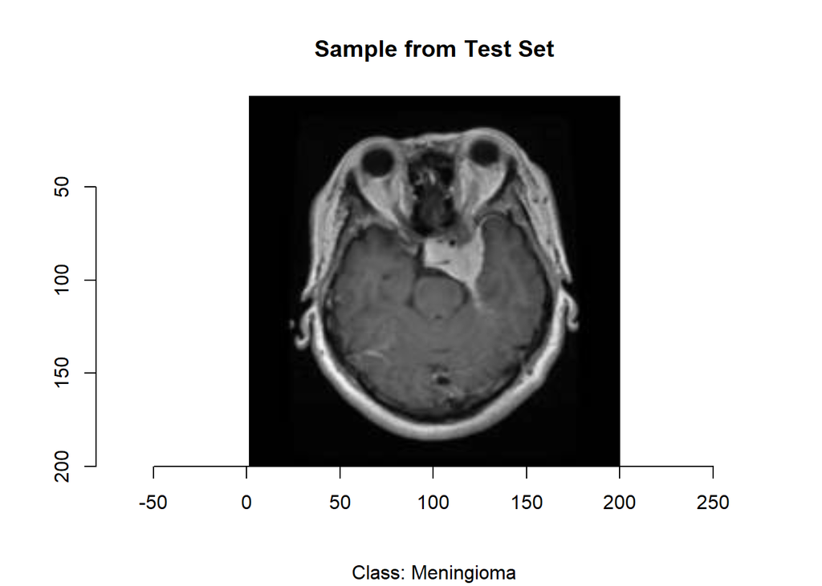

```r
# Display the 420th image from the Test set
plot(as.cimg(X_test_[420,,,]))
title(main = "Sample from Test Set", sub = paste0("Class: ", unlist(labels_test)[420]))
```

```r
# Create list of OvR training sets
X_train_ovr <- c()
labels_train_ovr <- c()

# Add all models in Adjusted OvR approach to the list
for(i in 1:(length(class) - 1)){
  remaining_classes <- class[i:length(class)]
  labels_train_ovr_ <- unlist(labels_train)[unlist(labels_train) %in% remaining_classes]
  idx_tr <- which(unlist(labels_train) %in% remaining_classes)
  X_train_ovr_ <- X_train_[idx_tr,,, , drop = FALSE]

  # Convert the response variable to binary
  labels_train_ovr_ <- ifelse(labels_train_ovr_ == class[i], 1, 0)  # Returns result in numeric format

  # Add to list
  X_train_ovr <- append(X_train_ovr, list(X_train_ovr_))
  labels_train_ovr <- append(labels_train_ovr, list(labels_train_ovr_))
}

# Create list of OvR test sets
X_test_ovr <- c()
labels_test_ovr <- c()

for(i in 1:(length(class) - 1)){
  remaining_classes <- class[i:length(class)]
  labels_test_ovr_ <- unlist(labels_test)[unlist(labels_test) %in% remaining_classes]
  idx_te <- which(unlist(labels_test) %in% remaining_classes)
  X_test_ovr_ <- X_test_[idx_te,,, , drop = FALSE]

  # Convert the response variable to binary
  labels_test_ovr_  <- ifelse(labels_test_ovr_ == class[i], 1, 0)  # Returns result in numeric format

  # Add to list
  X_test_ovr <- append(X_test_ovr, list(X_test_ovr_))
  labels_test_ovr <- append(labels_test_ovr, list(labels_test_ovr_))
}

# Create list of OvR validation sets
X_val_ovr <- c()
labels_val_ovr <- c()

for(i in 1:(length(class) - 1)){
  remaining_classes <- class[i:length(class)]
  labels_val_ovr_ <- unlist(labels_val)[unlist(labels_val) %in% remaining_classes]
  idx_v <- which(unlist(labels_val) %in% remaining_classes)
  X_val_ovr_ <- X_val_[idx_v,,, , drop = FALSE]

  # Convert the response variable to binary
  labels_val_ovr_  <- ifelse(labels_val_ovr_ == class[i], 1, 0)  # Returns result in numeric format

  # Add to list
  X_val_ovr <- append(X_val_ovr, list(X_val_ovr_))
  labels_val_ovr <- append(labels_val_ovr, list(labels_val_ovr_))
}
```

#### 9. Build the CNN models:

```r
my_models_ovr <- c()

for(i in 1:(length(class) - 1)){
  # Initialize the Sequential model
  my_model <- keras_model_sequential()  # All OvR models here have the same structure so there's actually no need to create a loop

  # Block 1
  my_model %>%
    layer_conv_2d(filters = 16, input_shape = c(200, 200, 1), kernel_size = c(3, 3), strides = c(1, 1), padding = 'same', name = 'Block_1_Conv_1') %>%
    layer_batch_normalization() %>%
    layer_activation('relu') %>%
    layer_conv_2d(filters = 32, kernel_size = c(3, 3), strides = c(1, 1), padding = 'same', name = 'Block_1_Conv_2') %>%
    layer_batch_normalization() %>%
    layer_activation('relu') %>%
    layer_max_pooling_2d(pool_size = c(2, 2), strides = c(2, 2), padding = 'same', name = 'Block_1_MaxPool') %>%
    layer_dropout(rate = 0.2)

  # Block 2
  my_model %>%
    layer_conv_2d(filters = 32, kernel_size = c(3, 3), strides = c(1, 1), padding = 'same', name = 'Block_2_Conv_1') %>%
    layer_batch_normalization() %>%
    layer_activation('relu') %>%
    layer_conv_2d(filters = 64, kernel_size = c(3, 3), strides = c(1, 1), padding = 'same', name = 'Block_2_Conv_2') %>%
    layer_batch_normalization() %>%
    layer_activation('relu') %>%
    layer_max_pooling_2d(pool_size = c(2, 2), strides = c(2, 2), padding = 'same', name = 'Block_2_MaxPool') %>%
    layer_dropout(rate = 0.2)

  # Block 3
  my_model %>%
    layer_conv_2d(filters = 64, kernel_size = c(3, 3), strides = c(1, 1), padding = 'same', name = 'Block_3_Conv_1') %>%
    layer_batch_normalization() %>%
    layer_activation('relu') %>%
    layer_conv_2d(filters = 128, kernel_size = c(3, 3), strides = c(1, 1), padding = 'same', name = 'Block_3_Conv_2') %>%
    layer_batch_normalization() %>%
    layer_activation('relu') %>%
    layer_max_pooling_2d(pool_size = c(2, 2), strides = c(2, 2), padding = 'same', name = 'Block_3_MaxPool') %>%
    layer_dropout(rate = 0.2)

  # Flatten
  my_model %>%
    layer_flatten()

  # Fully connected (FC) layer 1
  my_model %>%
    layer_dense(units = 64) %>%
    layer_batch_normalization() %>%
    layer_activation('relu') %>%
    layer_dropout(rate = 0.4)

  # Fully connected (FC) layer 2
  my_model %>%
    layer_dense(units = 1) %>%
    layer_activation('sigmoid')

  my_models_ovr <- append(my_models_ovr, list(my_model))
}

# Skip or keep summary (only 4 models max and if all 4 have the same hyperparameters then we only need to print 1 summary?)

# Summary of each model structure
cat(crayon::bold("Structure of each OvR model: \n"))
```

```
## Structure of each OvR model:
```

```r
summary(my_models_ovr[[1]])
```

```
## Model: "sequential"
## ________________________________________________________________________________
##  Layer (type)                  Output Shape               Param #    Trainable
## ================================================================================
##  Block_1_Conv_1 (Conv2D)       (None, 200, 200, 16)       160        Y
##  batch_normalization (BatchNor  (None, 200, 200, 16)      64         Y
##  malization)
##  activation (Activation)       (None, 200, 200, 16)       0          Y
##  Block_1_Conv_2 (Conv2D)       (None, 200, 200, 32)       4640       Y
##  batch_normalization_1 (BatchN  (None, 200, 200, 32)      128        Y
##  ormalization)
##  activation_1 (Activation)     (None, 200, 200, 32)       0          Y
##  Block_1_MaxPool (MaxPooling2D  (None, 100, 100, 32)      0          Y
##  )
##  dropout (Dropout)             (None, 100, 100, 32)       0          Y
##  Block_2_Conv_1 (Conv2D)       (None, 100, 100, 32)       9248       Y
##  batch_normalization_2 (BatchN  (None, 100, 100, 32)      128        Y
##  ormalization)
##  activation_2 (Activation)     (None, 100, 100, 32)       0          Y
##  Block_2_Conv_2 (Conv2D)       (None, 100, 100, 64)       18496      Y
##  batch_normalization_3 (BatchN  (None, 100, 100, 64)      256        Y
##  ormalization)
##  activation_3 (Activation)     (None, 100, 100, 64)       0          Y
##  Block_2_MaxPool (MaxPooling2D  (None, 50, 50, 64)        0          Y
##  )
##  dropout_1 (Dropout)           (None, 50, 50, 64)         0          Y
##  Block_3_Conv_1 (Conv2D)       (None, 50, 50, 64)         36928      Y
##  batch_normalization_4 (BatchN  (None, 50, 50, 64)        256        Y
##  ormalization)
##  activation_4 (Activation)     (None, 50, 50, 64)         0          Y
##  Block_3_Conv_2 (Conv2D)       (None, 50, 50, 128)        73856      Y
##  batch_normalization_5 (BatchN  (None, 50, 50, 128)       512        Y
##  ormalization)
##  activation_5 (Activation)     (None, 50, 50, 128)        0          Y
##  Block_3_MaxPool (MaxPooling2D  (None, 25, 25, 128)       0          Y
##  )
##  dropout_2 (Dropout)           (None, 25, 25, 128)        0          Y
##  flatten (Flatten)             (None, 80000)              0          Y
##  dense (Dense)                 (None, 64)                 5120064    Y
##  batch_normalization_6 (BatchN  (None, 64)                256        Y
##  ormalization)
##  activation_6 (Activation)     (None, 64)                 0          Y
##  dropout_3 (Dropout)           (None, 64)                 0          Y
##  dense_1 (Dense)               (None, 1)                  65         Y
##  activation_7 (Activation)     (None, 1)                  0          Y
## ================================================================================
## Total params: 5,265,057
## Trainable params: 5,264,257
## Non-trainable params: 800
## ________________________________________________________________________________
```

#### 10. Compile the models:

```r
pos_class <- head(class, -1)  # head(class, -1) is class without the last element

lr_ovr <- c()
lr_ovr <- ifelse(pos_class == "NoTumor", 0.01, ifelse(pos_class == "Glioma", 0.005, 0.005))

for(i in 1:(length(class) - 1)){
  my_models_ovr[[i]] %>%
    compile(loss = 'binary_crossentropy', optimizer = optimizer_sgd(learning_rate = lr_ovr[i], momentum = 0.8), metrics = list('AUC'))
}
```

#### 11. Train the models:

```r
############## Turn to comments from the second run onwards ###############
history_list <- c()
epoch_ovr <- c()
epoch_ovr <- ifelse(pos_class == "NoTumor", 10, ifelse(pos_class == "Glioma", 20, 25))

for(i in 1:(length(class) - 1)){
  remaining_classes <- class[i:length(class)]
  neg_labels <- paste0(label_map[remaining_classes[-1]], collapse = ", ")
  neg_labels_ <- paste0(label_map[remaining_classes[-1]], collapse = "-")

  if (i == length(class) - 1) {
    # Last model - only two classes left
    msg <- paste0("Adjusted OvR model ", label_map[class[i]], " vs ", neg_labels, ": \n")
    cat(crayon::bold(msg))
    }
  else {
    # Other models
    msg <- paste0("Adjusted OvR model ", label_map[class[i]], " vs ", "(", neg_labels, "): \n")
    cat(crayon::bold(msg))
  }

  # Create a callback ModelCheckpoint for each OvR problem. This callback will save the model weights when finding one better than the current best
  checkpoint_filepath <- paste0("braintumor_best_model_weights_", label_map[class[i]], "_vs_", neg_labels_, ".h5")

  mc <- callback_model_checkpoint(filepath = checkpoint_filepath, monitor = "val_loss", save_best_only = TRUE, save_weights_only = TRUE, save_freq = "epoch", verbose = 0)

  # Train the model
  history <- my_models_ovr[[i]] %>%
    fit(X_train_ovr[[i]], labels_train_ovr[[i]], batch_size = 16, epochs = epoch_ovr[i], verbose = 1, validation_data = list(X_val_ovr[[i]], labels_val_ovr[[i]]), callbacks = list(mc))
  history_list <- append(history_list, list(history))
  cat("\n")
}
```

```
## Adjusted OvR model NoT vs (Gl, Mn, Pt):
##
##
##
##
##
##
##
##
##
##
##
## Adjusted OvR model Gl vs (Mn, Pt):
##
##
##
##
##
##
##
##
##
##
##
##
##
##
##
##
##
##
##
##
##
## Adjusted OvR model Mn vs Pt:
##
##
##
##
##
##
##
##
##
##
##
##
##
##
##
##
##
##
##
##
##
##
##
##
##
```

#### 12. Plot training and validation AUC:

```
## Adjusted OvR model NoT vs (Gl, Mn, Pt):
```

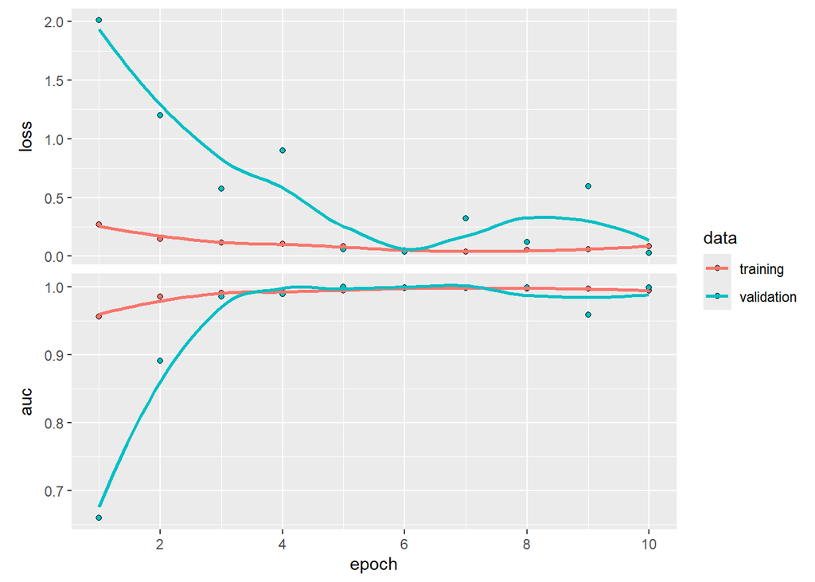

```
##
## Adjusted OvR model Gl vs (Mn, Pt):
```

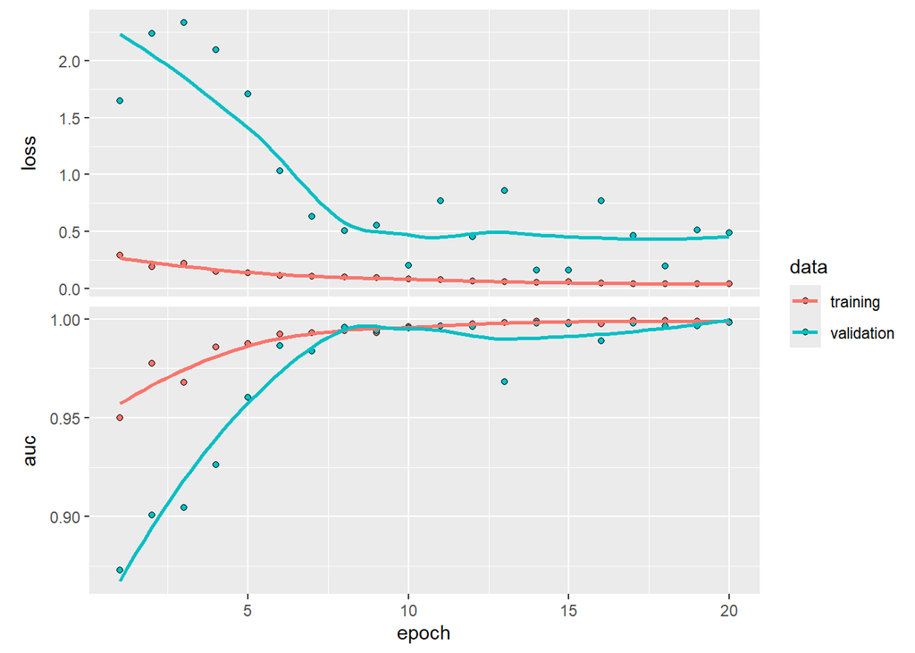

```
##
## Adjusted OvR model Mn vs Pt:
```

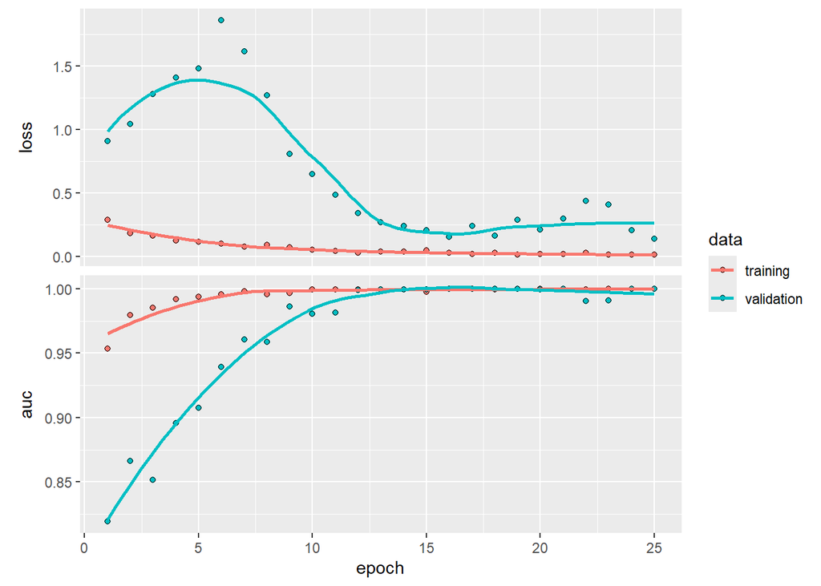

```r
############### Turn to comments from the second run onwards ###############
# Plot training and validation loss and AUC:
for(i in 1:(length(class) - 1)){
  remaining_classes <- class[i:length(class)]
  neg_labels <- paste0(label_map[remaining_classes[-1]], collapse = ", ")

  if (i == length(class) - 1) {
    # Last model - only two classes left
    msg <- paste0("Adjusted OvR model ", label_map[class[i]], " vs ", neg_labels, ": \n")
    cat(crayon::bold(msg))
    }
  else {
    # Other models
    msg <- paste0("Adjusted OvR model ", label_map[class[i]], " vs ", "(", neg_labels, "): \n")
    cat(crayon::bold(msg))
    }

  print(plot(history_list[[i]]))
  cat("\n")
}
```

#### 13. Using the saved best model weights, evaluate the model’s AUC on training and test set:

```r
output_train_ovr <- data.frame()
output_test_ovr <- data.frame()
labels_test_pred_ovr <- c()

for(i in 1:(length(class) - 1)){
  remaining_classes <- class[i:length(class)]
  neg_labels <- paste0(label_map[remaining_classes[-1]], collapse = ", ")
  neg_labels_ <- paste0(label_map[remaining_classes[-1]], collapse = "-")

  if (i == length(class) - 1) {
    # Last model - only two classes left
    mod <- paste0(label_map[class[i]], " vs ", neg_labels)
    }
  else {
    # Other models
    mod <- paste0(label_map[class[i]], " vs ", "(", neg_labels, ")")
  }

  # Load the saved best model weights to the model
  weights_filepath <- paste0("braintumor_best_model_weights_", label_map[class[i]], "_vs_", neg_labels_, ".h5")
  my_models_ovr[[i]] %>% load_model_weights_tf(weights_filepath)

  ### Evaluate the model on training set:
  eval_train <- evaluate(my_models_ovr[[i]], X_train_ovr[[i]], labels_train_ovr[[i]], verbose = 0)     # Compute training loss and AUC

  ### Evaluate the model on test set:
  labels_test_pred <- predict(my_models_ovr[[i]], X_test_ovr[[i]], verbose = 0)
  labels_test_pred_ovr <- append(labels_test_pred_ovr, list(labels_test_pred))

  eval_test <- evaluate(my_models_ovr[[i]], X_test_ovr[[i]], labels_test_ovr[[i]], verbose = 0)      # Compute test loss and AUC

  output_train_ovr <- rbind(output_train_ovr, data.frame(Model = mod, Loss = eval_train[1], AUC = eval_train[2]))
  output_test_ovr <- rbind(output_test_ovr, data.frame(Model = mod, Loss = eval_test[1], AUC = eval_test[2]))
}

labels_test_pred_ovr <- lapply(labels_test_pred_ovr, as.vector)

rownames(output_train_ovr) <- NULL
rownames(output_test_ovr) <- NULL

cat("Loss and AUC on the training set for each Adjusted OvR model: \n")
```

```
## Loss and AUC on the training set for each Adjusted OvR model:
```

```r
print(output_train_ovr)
```

```
##                 Model       Loss       AUC
## 1 NoT vs (Gl, Mn, Pt) 0.01086769 0.9999817
## 2      Gl vs (Mn, Pt) 0.06404608 0.9999385
## 3            Mn vs Pt 0.01743406 1.0000000
```

```r
cat("\n")
```

```r
cat("Loss and AUC on the test set for each Adjusted OvR model: \n")
```

```
## Loss and AUC on the test set for each Adjusted OvR model:
```

```r
print(output_test_ovr)
```

```
##                 Model       Loss       AUC
## 1 NoT vs (Gl, Mn, Pt) 0.02913978 0.9980397
## 2      Gl vs (Mn, Pt) 0.15163811 0.9954776
## 3            Mn vs Pt 0.28011245 0.9732502
```

### **B/ Choosing decision threshold by ROC curve and decision curve:**

#### 1. **Criterias to determine the decision threshold for the CNN model:**

```r
mod_names <- c()

for (i in 1:(length(class) - 1)) {
  remaining_classes <- class[i:length(class)]
  neg_labels <- paste0(label_map[remaining_classes[-1]], collapse = ", ")

  if (i == length(class) - 1) {
    # Last model - only two classes left
    mod_name <- paste0(label_map[class[i]], " vs ", neg_labels)
  }
  else {
    # Other models
    mod_name <- paste0(label_map[class[i]], " vs ", "(", neg_labels, ")")
  }

  mod_names <- c(mod_names, mod_name)
}
```

- **Youden index criterion:**

```r
# Optimal thresholds obtained by maximizing youden index
j_threshold <- function(y_true, y_pred) {
  roc_obj <- pROC::roc(y_true, y_pred)
  fpr <- 1 - roc_obj$specificities
  tpr <- roc_obj$sensitivities
  thresholds <- roc_obj$thresholds
  j <- tpr - fpr
  j <- sort(j, decreasing = TRUE, index.return = TRUE)
  j_ordered <- data.frame(j = j[1], thresholds = thresholds[rank(j$ix)])
  for (k in 1:nrow(j_ordered)){
    if (is.finite(j_ordered$thresholds[k])) {
      return(j_ordered$thresholds[k])
      break
      }
  }
}

cj_ovr <- c()

for (i in 1:(length(class) - 1)){
  cj <- j_threshold(labels_test_ovr[[i]], labels_test_pred_ovr[[i]])
  cj_ovr <- append(cj_ovr, cj)
}
names(cj_ovr) <- mod_names

cj_ovr
```

```
## NoT vs (Gl, Mn, Pt)      Gl vs (Mn, Pt)            Mn vs Pt
##          0.75128877          0.82267696          0.09279775
```

- **Closest to (0,1) criterion:**

```r
# Optimal threshold obtained by maximizing sensitivity and specificity to the extent that both are closest to 100%
d_threshold <- function(y_true, y_pred) {
  roc_obj <- pROC::roc(y_true, y_pred)
  fpr <- 1 - roc_obj$specificities
  tpr <- roc_obj$sensitivities
  thresholds <- roc_obj$thresholds
  d <- sapply(1:length(fpr), function(i) sqrt((1 - tpr[i])^2 + (fpr[i])^2))
  d <- sort(d, decreasing = FALSE, index.return = TRUE)
  d_ordered <- data.frame(d = d[1], thresholds = thresholds[rank(d$ix)])
  for (k in 1:nrow(d_ordered)){
    if (is.finite(d_ordered$thresholds[k])) {
      return(d_ordered$thresholds[k])
      break
      }
  }
}

cd_ovr <- c()

for (i in 1:(length(class) - 1)){
  cd <- d_threshold(labels_test_ovr[[i]], labels_test_pred_ovr[[i]])
  cd_ovr <- append(cd_ovr, cd)
}
names(cd_ovr) <- mod_names

cd_ovr
```

```
## NoT vs (Gl, Mn, Pt)      Gl vs (Mn, Pt)            Mn vs Pt
##          0.75128877          0.82267696          0.04816283
```

- **Symetric point criterion:**

```r
# Optimal threshold obtained by finding the point where sensitivity and specificity are equivalent
s_threshold <- function(y_true, y_pred) {
  roc_obj <- pROC::roc(y_true, y_pred)
  fpr <- 1 - roc_obj$specificities
  tpr <- roc_obj$sensitivities
  thresholds <- roc_obj$thresholds
  s <- abs(fpr + tpr - 1)
  s <- sort(s, decreasing = FALSE, index.return = TRUE)
  s_ordered <- data.frame(s = s[1], thresholds = thresholds[rank(s$ix)])
  for (k in 1:nrow(s_ordered)){
    if (is.finite(s_ordered$thresholds[k])) {
      return(s_ordered$thresholds[k])
      break
      }
  }
}

cs_ovr <- c()

for (i in 1:(length(class) - 1)){
  cs <- s_threshold(labels_test_ovr[[i]], labels_test_pred_ovr[[i]])
  cs_ovr <- append(cs_ovr, cs)
}
names(cs_ovr) <- mod_names

cs_ovr
```

```
## NoT vs (Gl, Mn, Pt)      Gl vs (Mn, Pt)            Mn vs Pt
##          0.75128877          0.80522388          0.02507351
```

#### 2. Plot ROC curve, decision curve and optimal thresholds for the CNN model:

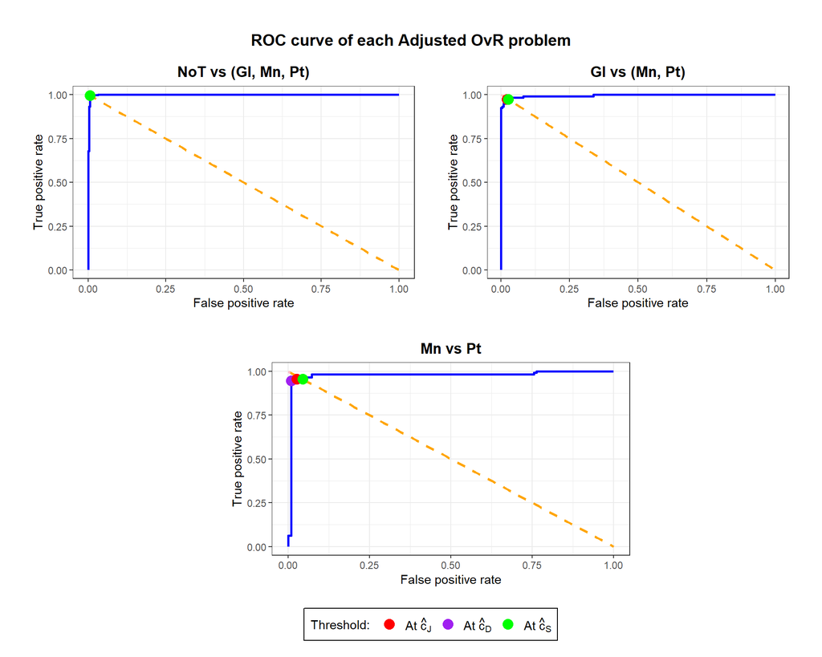

```r
# Plot ROC curve
thresholds_cnn_ovr <- c()
plot_list <- c()

for (i in 1:(length(class) - 1)){
  roc_obj <- pROC::roc(labels_test_ovr[[i]], labels_test_pred_ovr[[i]])
  thresholds_cnn <- roc_obj$thresholds
  thresholds_cnn_ovr <- append(thresholds_cnn_ovr, list(thresholds_cnn))
  roc_data <- data.frame(fpr = rev(1 - roc_obj$specificities), tpr = rev(roc_obj$sensitivities))

  for (k in 1:length(roc_obj$thresholds)){
    if (roc_obj$thresholds[k] == cj_ovr[i]){
      specificity_j <- roc_obj$specificities[k]
      sensitivity_j <- roc_obj$sensitivities[k]
    }
    if (roc_obj$thresholds[k] == cd_ovr[i]){
      specificity_d <- roc_obj$specificities[k]
      sensitivity_d <- roc_obj$sensitivities[k]
    }
    if (roc_obj$thresholds[k] == cs_ovr[i]){
      specificity_s <- roc_obj$specificities[k]
      sensitivity_s <- roc_obj$sensitivities[k]
    }
  }

  diagonal_data <- data.frame(x = seq(0, 1, length.out = 100), y = 1 - seq(0, 1, length.out = 100))
  thresholds_data <- data.frame(x1 = 0, x2 = 1 - specificity_d, y1 = 1, y2 = sensitivity_d)
  sp_se_j <- data.frame(sp = specificity_j, se = sensitivity_j)
  sp_se_d <- data.frame(sp = specificity_d, se = sensitivity_d)
  sp_se_s <- data.frame(sp = specificity_s, se = sensitivity_s)

  remaining_classes <- class[i:length(class)]
  neg_labels <- paste0(label_map[remaining_classes[-1]], collapse = ", ")

  if (i == length(class) - 1) {
    # Last model - only two classes left
    plot_title <- paste0(label_map[class[i]], " vs ", neg_labels)
    }
  else {
    # Other models
    plot_title <- paste0(label_map[class[i]], " vs ", "(", neg_labels, ")")
    }

  rc <- ggplot(data = roc_data, aes(x = fpr, y = tpr)) +
  geom_line(linetype = "solid", linewidth = 1, col = "blue") +
  geom_line(data = diagonal_data, aes(x = x, y = y), linetype = "dashed", linewidth = 1, col = "orange") +
  geom_segment(data = thresholds_data, aes(x = x1, y = y1, xend = x2, yend = y2), linetype = "dotdash", linewidth = 1, col = "pink") +
  geom_point(data = sp_se_j, aes(x = 1 - sp, y = se, col = "c_j"), size = 4, show.legend = TRUE) +
  geom_point(data = sp_se_d, aes(x = 1 - sp, y = se, col = "c_d"), size = 4, show.legend = TRUE) +
  geom_point(data = sp_se_s, aes(x = 1 - sp, y = se, col = "c_s"), size = 4, show.legend = TRUE) +
  labs(x = "False positive rate", y = "True positive rate") + ggtitle(plot_title) +
  scale_color_manual(name = "Threshold: ", labels = unname(TeX(c("At $\\hat{c}_{J}$", "At $\\hat{c}_{D}$", "At $\\hat{c}_{S}$"))), values=c("red", "purple", "green")) +
  theme_bw() +
  theme(plot.title = element_text(face="bold", hjust = 0.5, size = 13))
  plot_list[[i]] <- rc
}
names(plot_list) <- c("A", "B", "C")

layout <- "AABB
           #CC#"

# Combine all plots in the list into a grid layout (2 columns)
combined_plot <- wrap_plots(plot_list, design = layout, ncol = 2)

legend <- get_legend(plot_list[[1]])
# Arrange the combined plot with a shared legend and title
final_plot <- combined_plot + plot_layout(guides = "collect") &
  theme(plot.margin = unit(c(2, 1, 0, 1), "lines"), legend.position = "bottom", legend.background = element_rect(color = "black", size = 0.5, linetype = "solid"), legend.text = element_text(size = 11), legend.box.margin = unit(c(0.6, 1, 1, 1), "lines"))   # Add 2 lines at the top (plot.margin = unit(c(top,right,bottom,left), "lines")
print(final_plot)
grid.text("ROC curve of each Adjusted OvR problem", x = 0.5, y = 0.94, gp = gpar(fontsize = 14, fontface = "bold"))
```

```r
# Plot decision curve

# Net benefit function
nb <- function(y_true, y_pred, c, prev){
  roc_obj <- pROC::roc(y_true, y_pred)
  for (i in 1:length(roc_obj$thresholds)){
    if (roc_obj$thresholds[i] == c){
      se_c <- roc_obj$sensitivities[i]
      sp_c <- roc_obj$specificities[i]
      break
    }
  }
  phi_c <- se_c * prev - (1 - sp_c) * (1 - prev) * c/(1 - c)
  return(phi_c)
}

plot_list <- c()

for (i in 1:(length(class) - 1)){
  # Calculate disease prevalence in the population:
  # p = number of diseased / total population size (calculate from whole dataset (labels) or just test set (labels_test)?)
  p <- sum(labels_test_ovr[[i]]) / length(labels_test_ovr[[i]])

  df_cnn <- data.frame(labels_test_pred_ = labels_test_pred_ovr[[i]], labels_test_ = labels_test_ovr[[i]])
  nb_j <- data.frame(cj = cj_ovr[i], nbj = nb(labels_test_ovr[[i]], labels_test_pred_ovr[[i]], cj_ovr[i], p))
  nb_d <- data.frame(cd = cd_ovr[i], nbd = nb(labels_test_ovr[[i]], labels_test_pred_ovr[[i]], cd_ovr[i], p))
  nb_s <- data.frame(cs = cs_ovr[i], nbs = nb(labels_test_ovr[[i]], labels_test_pred_ovr[[i]], cs_ovr[i], p))

  remaining_classes <- class[i:length(class)]
  neg_labels <- paste0(label_map[remaining_classes[-1]], collapse = ", ")

  if (i == length(class) - 1) {
    # Last model - only two classes left
    plot_title <- paste0(label_map[class[i]], " vs ", neg_labels)
    }
  else {
    # Other models
    plot_title <- paste0(label_map[class[i]], " vs ", "(", neg_labels, ")")
    }

  # For the Decision curve plot, use the thresholds values from ROC curve plot to make sure that the optimal thresholds show on the decision curve correctly
  dca_obj <- dcurves::dca(labels_test_ ~ labels_test_pred_, data = df_cnn, label = list(labels_test_pred_ = "CNN model"), thresholds = thresholds_cnn_ovr[[i]], prevalence = p)
  dc <- plot(dca_obj, smooth = FALSE) + geom_line(linewidth = 1) +
    ggtitle(plot_title) +
    geom_point(data = nb_j, aes(x = cj, y = nbj, col = "c_j"), size = 4, show.legend = TRUE) +
    geom_point(data = nb_d, aes(x = cd, y = nbd, col = "c_d"), size = 4, show.legend = TRUE) +
    geom_point(data = nb_s, aes(x = cs, y = nbs, col = "c_s"), size = 4, show.legend = TRUE) +
    scale_color_manual(labels = unname(TeX(c("Treat All", "Treat None", "CNN model", "At $\\hat{c}_{J}$", "At $\\hat{c}_{D}$", "At $\\hat{c}_{S}$"))), values=c("orange", "pink", "blue", "red", "purple", "green")) +
    guides(colour = guide_legend(byrow = TRUE, override.aes = list(linetype = c("solid", "solid", "solid", rep("blank", 3)), shape = c(NA, NA, NA, rep(16, 3))))) + theme(plot.title = element_text(face="bold", hjust = 0.5, size = 13))
  plot_list[[i]] <- dc
}
```

```
## Assuming '1' is [Event] and '0' is [non-Event]
```

```
## Assuming '1' is [Event] and '0' is [non-Event]
```

```
## Assuming '1' is [Event] and '0' is [non-Event]
```

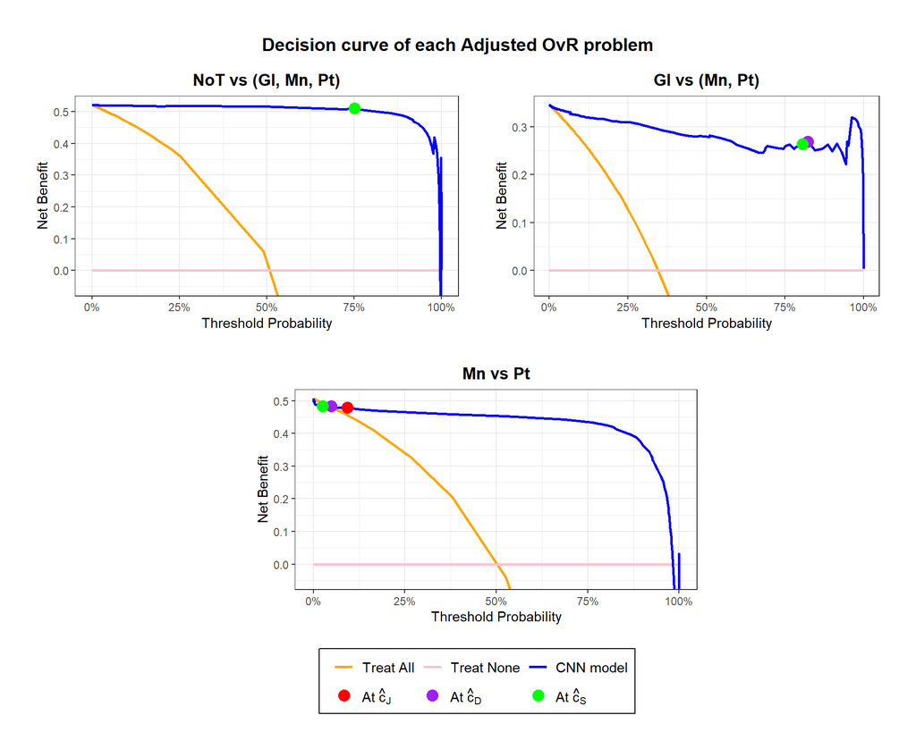

```r
names(plot_list) <- c("A", "B", "C")

layout <- "AABB
           #CC#"

# Combine all plots in the list into a grid layout (2 columns)
combined_plot <- wrap_plots(plot_list, design = layout, ncol = 2)

legend <- get_legend(plot_list[[1]])
# Arrange the combined plot with a shared legend and title
final_plot <- combined_plot + plot_layout(guides = "collect") &
  theme(plot.margin = unit(c(2, 1, 0, 1), "lines"), legend.position = "bottom", legend.background = element_rect(color = "black", size = 0.5, linetype = "solid"), legend.text = element_text(size = 11), legend.box.margin = unit(c(0.6, 1, 1, 1), "lines"))   # Add 2 lines at the top (plot.margin = unit(c(top,right,bottom,left), "lines")

print(final_plot)
grid.text("Decision curve of each Adjusted OvR problem", x = 0.5, y = 0.94, gp = gpar(fontsize = 14, fontface = "bold"))
```

```r
best_thresholds <- c()
c_res <- c()

for (i in 1:(length(class) - 1)) {
  p <- sum(labels_test_ovr[[i]]) / length(labels_test_ovr[[i]])

  nb_j <- nb(labels_test_ovr[[i]], labels_test_pred_ovr[[i]], unname(cj_ovr[i]), p)
  nb_d <- nb(labels_test_ovr[[i]], labels_test_pred_ovr[[i]], unname(cd_ovr[i]), p)
  nb_s <- nb(labels_test_ovr[[i]], labels_test_pred_ovr[[i]], unname(cs_ovr[i]), p)
  nb_values <- c(cj = nb_j, cd = nb_d, cs = nb_s)

  best_threshold <- names(which.max(nb_values))   # Name of the threshold with highest net benefit
  best_thresholds <- c(best_thresholds, best_threshold)
  threshold_map <- list(cj = cj_ovr[i], cd = cd_ovr[i], cs = cs_ovr[i])
  c_res <- c(c_res, threshold_map[[best_threshold]])   # Get the optimal threshold's value
}
cat(crayon::bold("Optimal threshold of each Adjusted OvR model: \n"))
```

```
## Optimal threshold of each Adjusted OvR model:
```

```r
for (i in 1:(length(class) - 1)) {
  cat(mod_names[i], ": ", best_thresholds[i], " = ", c_res[i], "\n", sep = "")
}
```

```
## NoT vs (Gl, Mn, Pt): cj = 0.7512888
## Gl vs (Mn, Pt): cj = 0.822677
## Mn vs Pt: cs = 0.02507351
```

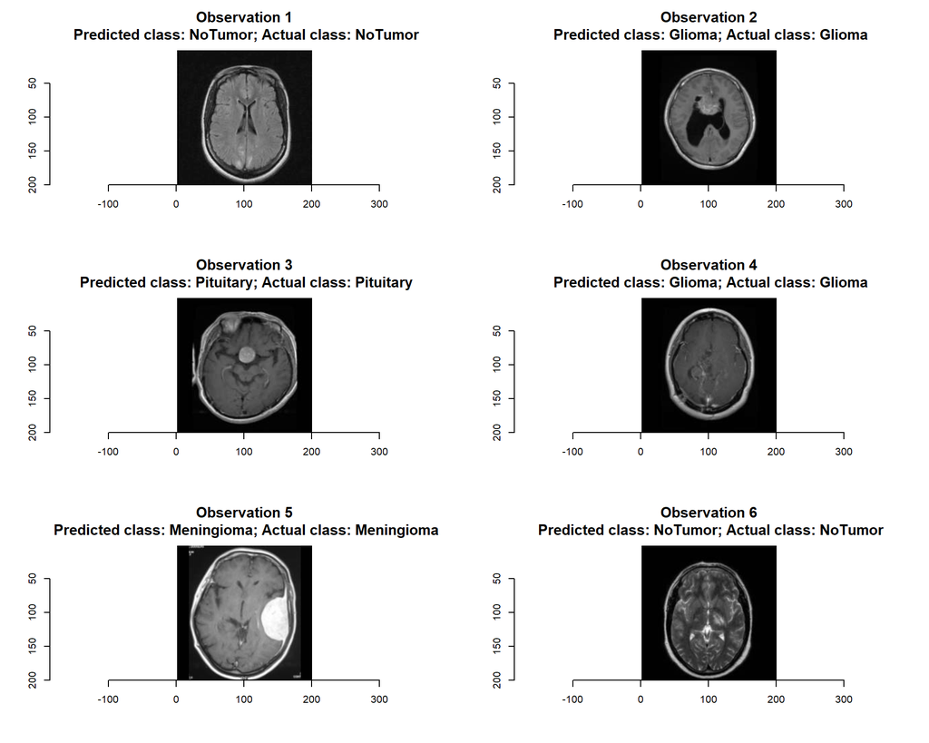

```r
## Example: Predicting the class of a new data point with CNN model
new_obs_ <- X_test[2:7]  # Some observations from the test set
new_obs <- do.call(abind, new_obs_)
new_obs <- aperm(new_obs, perm = c(4,1,2,3))
# In the procedure: You need to preprocess (Convert into the correct format, Resize, Normalize, Reshape, ... in the same method and with the same values calculated from the preprocessing step of the training set) the new data if needed
actual_classes <- labels_test[2:7]
class_preds <- c()
mods_data <- c()

for (i in 1:nrow(new_obs)) {
  pred_class <- NA  # Default if no model meets threshold
  labels_pred_ovr <- c()

  # Sequentially check each Adjusted OvR model
  for (j in 1:(length(class) - 1)) {
    # Predict probability
    labels_pred <- predict(my_models_ovr[[j]], new_obs[i,,, , drop = FALSE], verbose = 0)
    labels_pred <- round(labels_pred, digits = 7)
    labels_pred_ovr <- c(labels_pred_ovr, labels_pred)

    # Compare with threshold
    if (labels_pred >= c_res[j]) {  # thresholds[j] is the optimal threshold for the j-th Adjusted OvR model
      pred_class <- class[j]  # Predict as the positive class of this model
      break  # Stop at first model that meets the threshold
    }
  }

  # If none met the threshold, assign to the last class
  if (is.na(pred_class)) {
    pred_class <- class[length(class)]
  }

  class_preds <- c(class_preds, pred_class)

  # Save all model's probabilities
  if (length(labels_pred_ovr) < (length(class) - 1)) {
    labels_pred_ovr <- c(labels_pred_ovr, rep(NA, (length(class) - 1) - length(labels_pred_ovr)))   # Making predicted probabilities vector of all samples have the same length
  }

  mods_data[[i]] <- c(paste0("Observation ", i), labels_pred_ovr)
}

# Final result
par(mfrow = c(3, 2))  # Create subplots with 2 rows and 3 columns

for (i in 1:nrow(new_obs)){
  plot(as.cimg(new_obs[i,,,]))
  title(main =  paste0("Observation ", i, "\n Predicted class: ", class_preds[i], "; Actual class: ", actual_classes[i]), cex.main = 1.4)
}
```

```r
# Specifically, each model's predicted probabilities are as follows
mods_prob <- do.call(rbind, mods_data)
colnames(mods_prob) <- c("Observation", mod_names)
mods_prob <- as.data.frame(mods_prob)
print(mods_prob)
```

```
##     Observation NoT vs (Gl, Mn, Pt) Gl vs (Mn, Pt) Mn vs Pt
## 1 Observation 1           0.9989261           <NA>     <NA>
## 2 Observation 2           0.0020926      0.9980562     <NA>
## 3 Observation 3           0.0036063      0.0461544 1.85e-05
## 4 Observation 4           0.0007578      0.9992962     <NA>
## 5 Observation 5           0.0866392       0.016209  0.89604
## 6 Observation 6            0.997558           <NA>     <NA>
```